# Probabilidad e Inferencia Estadística

Jeisson Rodriguez Rodriguez

2024-09-16

A continuación se presentan un problema de probabilidad e inferencia estadística, el problema habla sobre el Teorema del Limite Central.

## PROBLEMA 3 - TEOREMA DEL LIMITE CENTRAL

El Teorema del Límite Central es uno de los más importantes en la inferencia estadística y habla sobre la convergencia de los estimadores como la proporción muestral a la distribución normal. Algunos autores afirman que esta aproximación es bastante buena a partir del umbral $n >30$.

A continuación se describen los siguientes pasos para su verificación:

**a.** Realice una simulación en la cual genere una población de $n=1000$ (Lote), donde el porcentaje de individuos (supongamos plantas) enfermas sea del $50%$.

**b.** Genere una función que permita: - Obtener una muestra aleatoria de la población y - Calcule el estimador de la proporción muestral $\hat{p}$ para un tamaño de muestra dado $n$.

**c.** Repita el escenario anterior (b) $500$ veces y analice los resultados en cuanto al comportamiento de los $500$ resultados del estimador $\hat{p}$.¿Qué tan simétricos o sesgados son los resultados obtenidos? y ¿qué se puede observar en cuanto a la variabilidad?. Realice en su informe un comentario sobre los resultados obtenidos.

**d.** Repita los puntos b y c para tamaños de muestra $n=5,10,15,20,30,50,60,100,200,500$. Compare los resultados obtenidos para los diferentes tamaños de muestra en cuanto a la normalidad. Utilice pruebas de bondad y ajuste *(shapiro wilks :shaspiro.test())* y métodos gráficos *(gráfico de normalidad: qqnorm())*. Comente en su informe los resultados obtenidos.

**e.** Repita toda la simulación *(puntos a – d)*, pero ahora para lotes con $10%$ de plantas enfermas y de nuevo para lotes con un $90%$ de plantas enfermas. Concluya sobre los resultados del ejercicio.

## SOLUCIÓN

**a.**

Generamos de un lote de $1000$, una población con distribución Binomial donde el porcentaje de individuos enfermos es del $50%$, esto es:

```r
poblacion <- rbinom(1,size=1000,prob=0.5)
```

**b.**

Definimos una función donde se obtenga una muestra aleatoria y de ella se calcula un estimador de la proporción muestral $\hat{p}$ para un tamaño de muestra dado:

```r
P.Enfermas <- poblacion
P.Sanas <- 1000 - P.Enfermas
Datos.Poblacion <- c(rep("enfermas",P.Enfermas), rep("sanas",P.Sanas))

Muestra.Aleatoria = function(tamaño,criterio) {
    muestra <- sample(Datos.Poblacion, size = tamaño)
    P.Muestral <- sum(muestra == criterio)/tamaño
    #print(P.Muestral)
}
```

**c.**

Ahora definimos otra función para que repita lo anterior $500$ veces y arroje los resultados asi:

```r
Muestra.Aleatoria500 = function(tamaño,criterio){
  resultadosEst <- array(NA,500)
  for (i in 1:500) {
      resultadosEst[i] <- Muestra.Aleatoria(tamaño,criterio)
  }
  print(resultadosEst)

  #---------------------------------------------------------

  summary(resultadosEst)
}
```

Para ello hacemos la prueba con un tamaño de $300$ y criterio *“Sanas”*, esto es:

```r
Muestra.Aleatoria500(300,"sanas")
```

```
##   [1] 0.4733333 0.5100000 0.5266667 0.4800000 0.5166667 0.5333333 0.5100000
##   [8] 0.5300000 0.5200000 0.5166667 0.5033333 0.4400000 0.5033333 0.5066667
##  [15] 0.5566667 0.5200000 0.5100000 0.4966667 0.5133333 0.5233333 0.5033333
##  [22] 0.5266667 0.5100000 0.5166667 0.5266667 0.4933333 0.5500000 0.5333333
##  [29] 0.5300000 0.5133333 0.5600000 0.5000000 0.5466667 0.4966667 0.5033333
##  [36] 0.5266667 0.5066667 0.5400000 0.5333333 0.5233333 0.4966667 0.5300000
##  [43] 0.4933333 0.4933333 0.5633333 0.5100000 0.5300000 0.5166667 0.5033333
##  [50] 0.5266667 0.5233333 0.5433333 0.5300000 0.5100000 0.5500000 0.5700000
##  [57] 0.5166667 0.5266667 0.5200000 0.5166667 0.5000000 0.5200000 0.5400000
##  [64] 0.5500000 0.4900000 0.5333333 0.5600000 0.5000000 0.5000000 0.5566667
##  [71] 0.5466667 0.5300000 0.5166667 0.5033333 0.5433333 0.5200000 0.5333333
##  [78] 0.5300000 0.5333333 0.4900000 0.5666667 0.5400000 0.4833333 0.5400000
##  [85] 0.5066667 0.5033333 0.5533333 0.4933333 0.5666667 0.5166667 0.5733333
##  [92] 0.5633333 0.4633333 0.4833333 0.5466667 0.5100000 0.5400000 0.5333333
##  [99] 0.5100000 0.5400000 0.5266667 0.5366667 0.5500000 0.5233333 0.5133333
```

[output cut: 57 more lines]

```
##    Min. 1st Qu.  Median    Mean 3rd Qu.    Max.
##  0.4400  0.5033  0.5167  0.5172  0.5300  0.5900
```

En primer momento se puede observar que los resultados tienden a ser simétricos, su sesgo es pequeño, su media y mediana son muy semejantes, su variabilidad es mínima y su presume que su distribución tiende a una normalidad.

**d.**

Para repetir este procedimiento con los tamaños de muestra $n=5,10,15,20,30,50,60,100,200,500$, se modifica y adiciona al código la prueba de *Shapiro Wilks*, gráficos Boxplot, histogramas, gráficos de normalidad como sigue:

```r
Muestra.Aleatoria.n = function(tamaño,criterio){
  resultadosEst <- array(NA,500)
  for (i in 1:500) {
      resultadosEst[i] <- Muestra.Aleatoria(tamaño,criterio)
  }

  #---------------------------------------------------------

  summary(resultadosEst)

  shapiro_result <- shapiro.test(resultadosEst)
  print(shapiro_result)

  par(mfrow= c(1,3))

  boxplot(resultadosEst,col="red",xlab = "500 resultados del estimador",ylab="resultadosEst",main="BoxPlot")

  hist(resultadosEst,col="red",main="Histograma",freq = F)
  r <- density(resultadosEst)
  lines(r)
  lines(r, col = "blue",lwd = 3)
  promedio = mean(resultadosEst)
  abline(v=promedio, col="green", lwd=3)


  qqnorm(resultadosEst,main="Gráfico de Normalidad")
  qqline(resultadosEst,col = 'green', lwd = 2, lty = 2)

  summary(resultadosEst)
}
```

**n = 5 y criterio = “enfermas**

```r
Muestra.Aleatoria.n(5,"enfermas")
```

```
##
##  Shapiro-Wilk normality test
##
## data:  resultadosEst
## W = 0.9311, p-value = 2.085e-14
```

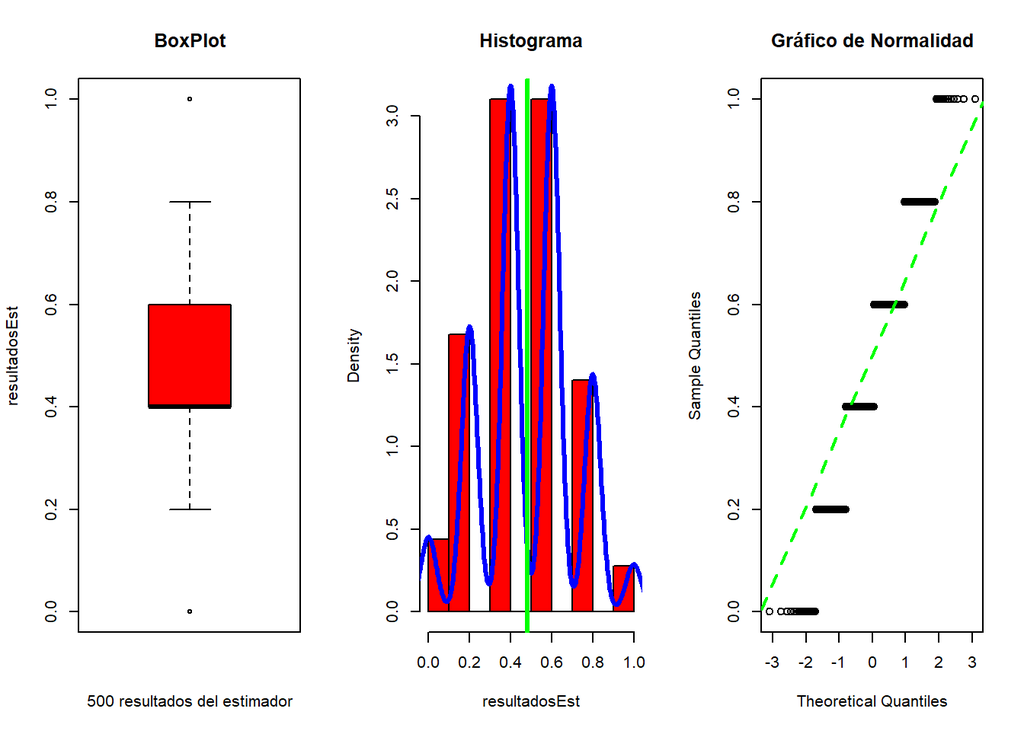

```
##    Min. 1st Qu.  Median    Mean 3rd Qu.    Max.
##  0.0000  0.4000  0.4000  0.4836  0.6000  1.0000
```

**n = 10 y criterio = “enfermas**

```r
Muestra.Aleatoria.n(10,"enfermas")
```

```
##
##  Shapiro-Wilk normality test
##
## data:  resultadosEst
## W = 0.9619, p-value = 4.349e-10
```

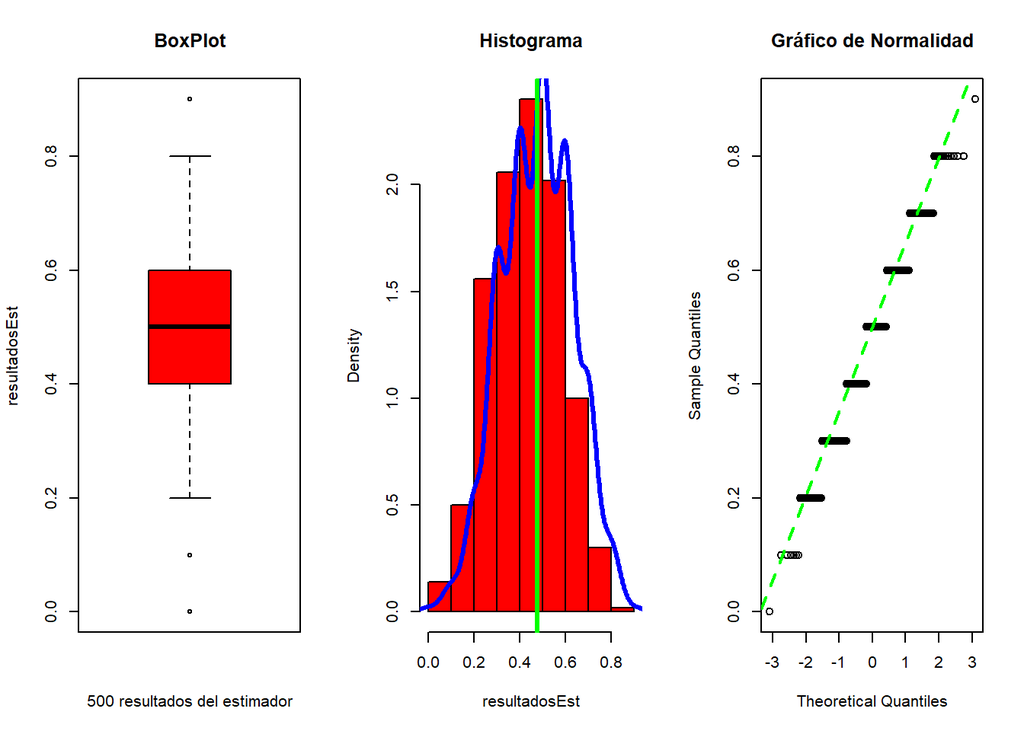

```
##    Min. 1st Qu.  Median    Mean 3rd Qu.    Max.
##  0.0000  0.4000  0.5000  0.4774  0.6000  0.9000
```

**n = 15 y criterio = “enfermas**

```r
Muestra.Aleatoria.n(15,"enfermas")
```

```
##
##  Shapiro-Wilk normality test
##
## data:  resultadosEst
## W = 0.97687, p-value = 4.068e-07
```

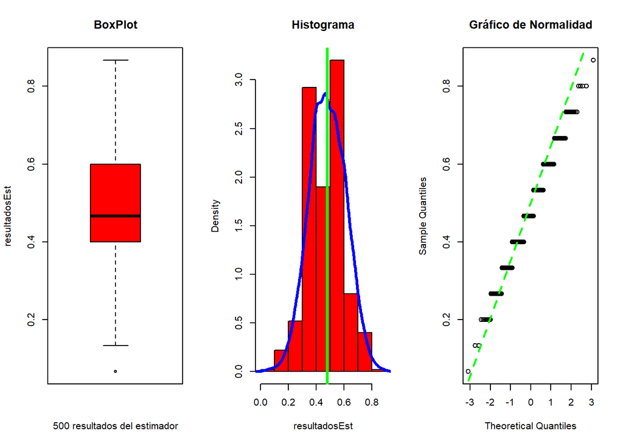

```
##    Min. 1st Qu.  Median    Mean 3rd Qu.    Max.
## 0.06667 0.40000 0.46667 0.48173 0.60000 0.86667
```

**n = 20 y criterio = “enfermas**

```r
Muestra.Aleatoria.n(20,"enfermas")
```

```
##
##  Shapiro-Wilk normality test
##
## data:  resultadosEst
## W = 0.97992, p-value = 2.195e-06
```

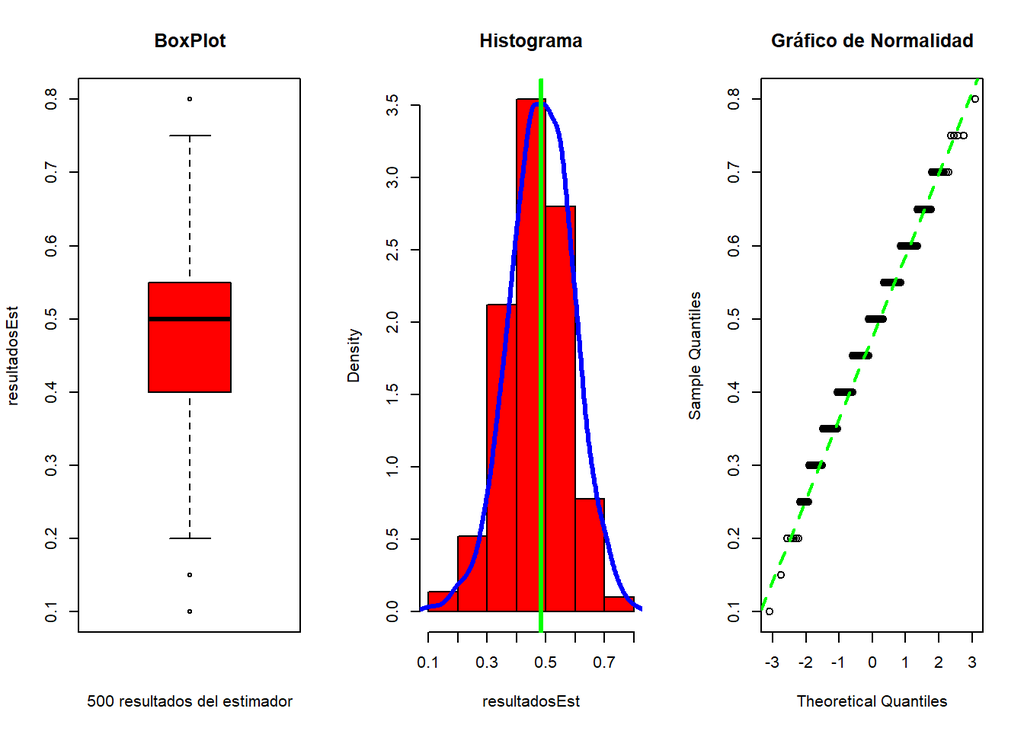

```
##    Min. 1st Qu.  Median    Mean 3rd Qu.    Max.
##  0.1000  0.4000  0.5000  0.4854  0.5500  0.8000
```

**n = 30 y criterio = “enfermas**

```r
Muestra.Aleatoria.n(30,"enfermas")
```

```
##
##  Shapiro-Wilk normality test
##
## data:  resultadosEst
## W = 0.98529, p-value = 6.06e-05
```

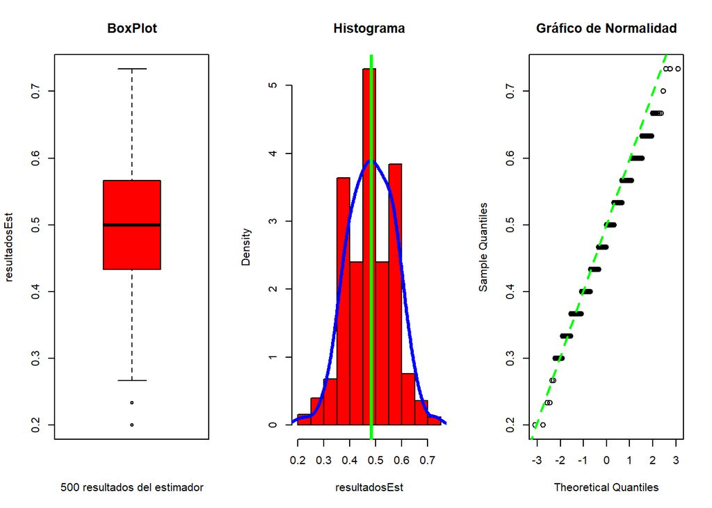

```
##    Min. 1st Qu.  Median    Mean 3rd Qu.    Max.
##  0.2000  0.4333  0.5000  0.4837  0.5667  0.7333
```

**n = 50 y criterio = “enfermas**

```r
Muestra.Aleatoria.n(50,"enfermas")
```

```
##
##  Shapiro-Wilk normality test
##
## data:  resultadosEst
## W = 0.99058, p-value = 0.002791
```

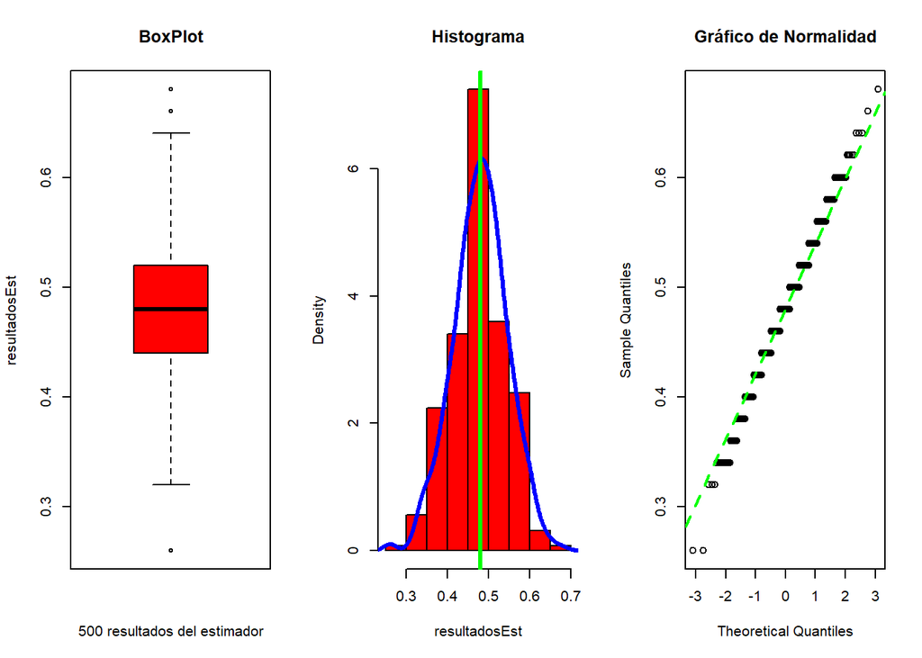

```
##    Min. 1st Qu.  Median    Mean 3rd Qu.    Max.
##  0.2600  0.4400  0.4800  0.4802  0.5200  0.6800
```

**n = 60 y criterio = “enfermas**

```r
Muestra.Aleatoria.n(60,"enfermas")
```

```
##
##  Shapiro-Wilk normality test
##
## data:  resultadosEst
## W = 0.99147, p-value = 0.005625
```

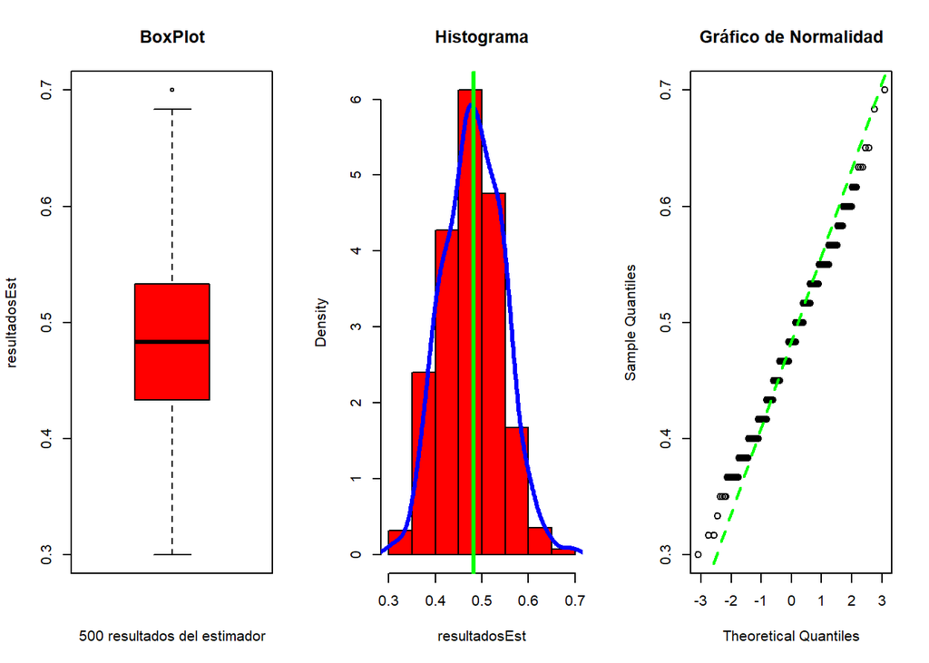

```
##    Min. 1st Qu.  Median    Mean 3rd Qu.    Max.
##  0.3000  0.4333  0.4833  0.4821  0.5333  0.7000
```

**n = 100 y criterio = “enfermas**

```r
Muestra.Aleatoria.n(100,"enfermas")
```

```
##
##  Shapiro-Wilk normality test
##
## data:  resultadosEst
## W = 0.99334, p-value = 0.02623
```

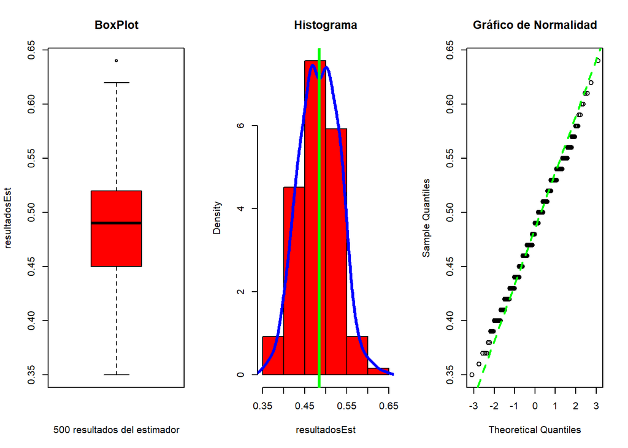

```
##    Min. 1st Qu.  Median    Mean 3rd Qu.    Max.
##  0.3500  0.4500  0.4900  0.4845  0.5200  0.6400
```

**n = 200 y criterio = “enfermas**

```r
Muestra.Aleatoria.n(200,"enfermas")
```

```
##
##  Shapiro-Wilk normality test
##
## data:  resultadosEst
## W = 0.994, p-value = 0.04566
```

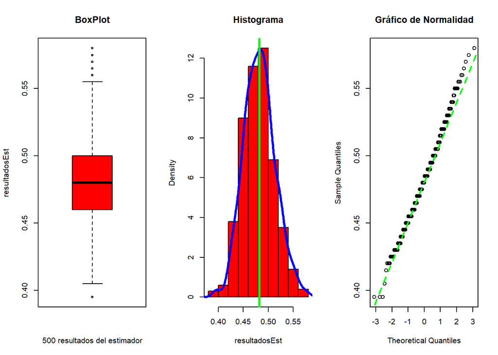

```
##    Min. 1st Qu.  Median    Mean 3rd Qu.    Max.
##  0.3950  0.4600  0.4800  0.4824  0.5000  0.5800
```

**n = 500 y criterio = “enfermas**

```r
Muestra.Aleatoria.n(500,"enfermas")
```

```
##
##  Shapiro-Wilk normality test
##
## data:  resultadosEst
## W = 0.99519, p-value = 0.1235
```

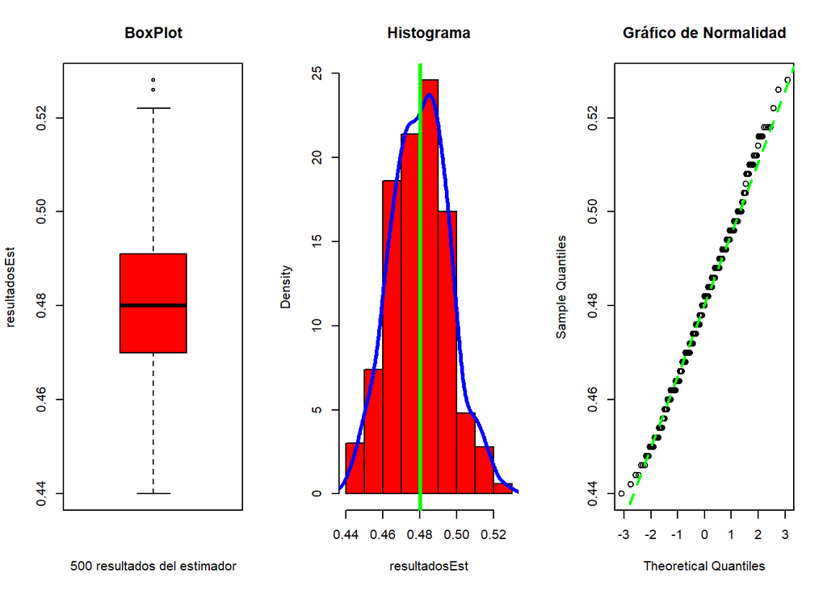

```
##    Min. 1st Qu.  Median    Mean 3rd Qu.    Max.
##  0.4400  0.4700  0.4800  0.4804  0.4905  0.5280
```

**e.**

Ahora, en el lote de $1000$, siguiendo una población con distribución Binomial el porcentaje de individuos enfermos cambia al $10%$, asi:

```r
poblacion10 <- rbinom(1,size=1000,prob=0.1)
```

y ajustamos el mismo código con la nueva población:

```r
P.Enfermas <- poblacion10
P.Sanas <- 1000 - P.Enfermas
Datos.Poblacion10 <- c(rep("enfermas",P.Enfermas), rep("sanas",P.Sanas))

Muestra.Aleatoria10 = function(tamaño,criterio) {
  muestra <- sample(Datos.Poblacion10, size = tamaño)
  P.Muestral <- sum(muestra == criterio)/tamaño
}

Muestra.Aleatoria.n10 = function(tamaño,criterio){
  resultadosEst10 <- array(NA,500)
  for (i in 1:500) {
    resultadosEst10[i] <- Muestra.Aleatoria10(tamaño,criterio)
    }

  #---------------------------------------------------------

  summary(resultadosEst10)

  Shapiro <- shapiro.test(resultadosEst10)
  print(Shapiro)

  par(mfrow= c(1,3))

  boxplot(resultadosEst10,col="red",xlab = "500 resultados del estimador",ylab="resultadosEst10",main="BoxPlot")

  hist(resultadosEst10,col="red",main="Histograma",freq = F)
  r <- density(resultadosEst10)
  lines(r)
  lines(r, col = "blue",lwd = 3)
  promedio = mean(resultadosEst10)
  abline(v=promedio, col="green", lwd=3)

  qqnorm(resultadosEst10,main="Gráfico de Normalidad")
  qqline(resultadosEst10,col = 'green', lwd = 2, lty = 2)

  summary(resultadosEst10)
}
```

**n = 5 y criterio = “enfermas**

```r
Muestra.Aleatoria.n10(5,"enfermas")
```

```
##
##  Shapiro-Wilk normality test
##
## data:  resultadosEst10
## W = 0.72968, p-value < 2.2e-16
```

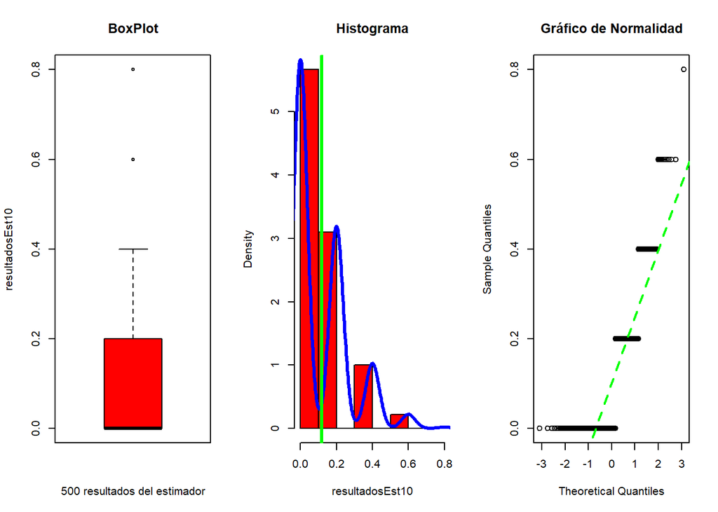

```
##    Min. 1st Qu.  Median    Mean 3rd Qu.    Max.
##  0.0000  0.0000  0.0000  0.1168  0.2000  0.8000
```

**n = 10 y criterio = “enfermas**

```r
Muestra.Aleatoria.n10(10,"enfermas")
```

```
##
##  Shapiro-Wilk normality test
##
## data:  resultadosEst10
## W = 0.84498, p-value < 2.2e-16
```

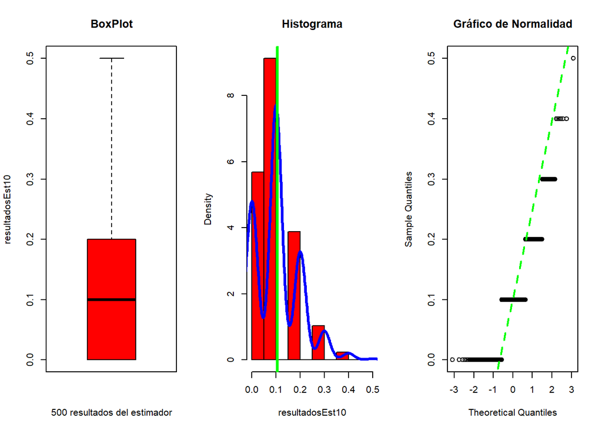

```
##    Min. 1st Qu.  Median    Mean 3rd Qu.    Max.
##  0.0000  0.0000  0.1000  0.1058  0.2000  0.5000
```

**n = 15 y criterio = “enfermas**

```r
Muestra.Aleatoria.n10(15,"enfermas")
```

```
##
##  Shapiro-Wilk normality test
##
## data:  resultadosEst10
## W = 0.90492, p-value < 2.2e-16
```

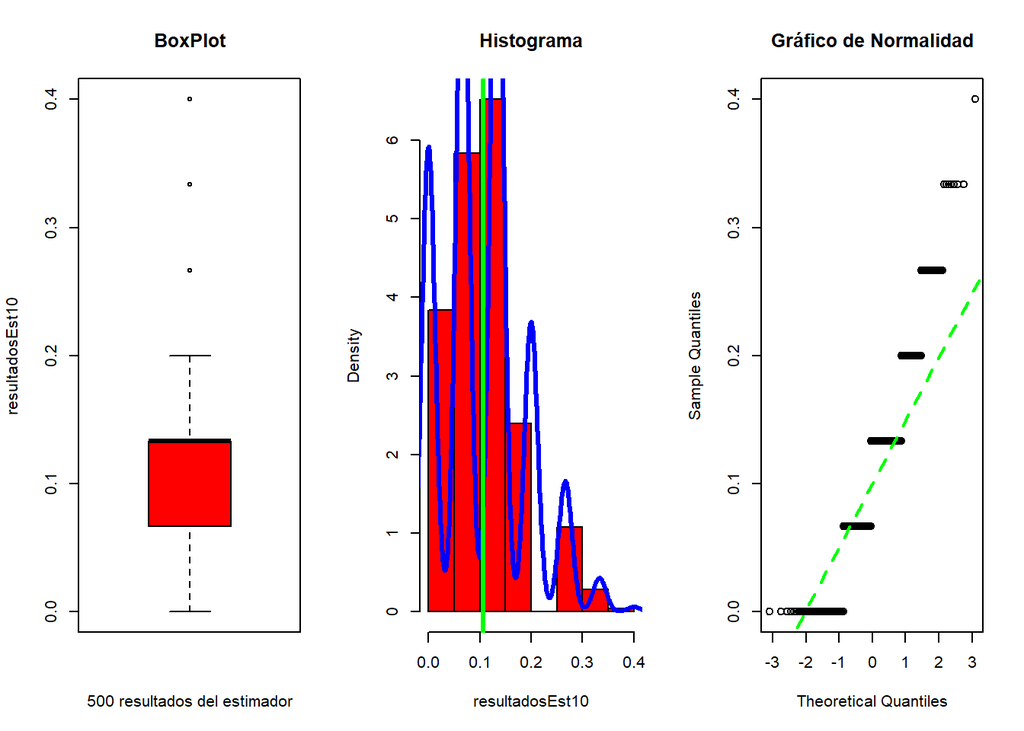

```
##    Min. 1st Qu.  Median    Mean 3rd Qu.    Max.
## 0.00000 0.06667 0.13333 0.10680 0.13333 0.40000
```

**n = 20 y criterio = “enfermas**

```r
Muestra.Aleatoria.n10(20,"enfermas")
```

```
##
##  Shapiro-Wilk normality test
##
## data:  resultadosEst10
## W = 0.93458, p-value = 5.386e-14
```

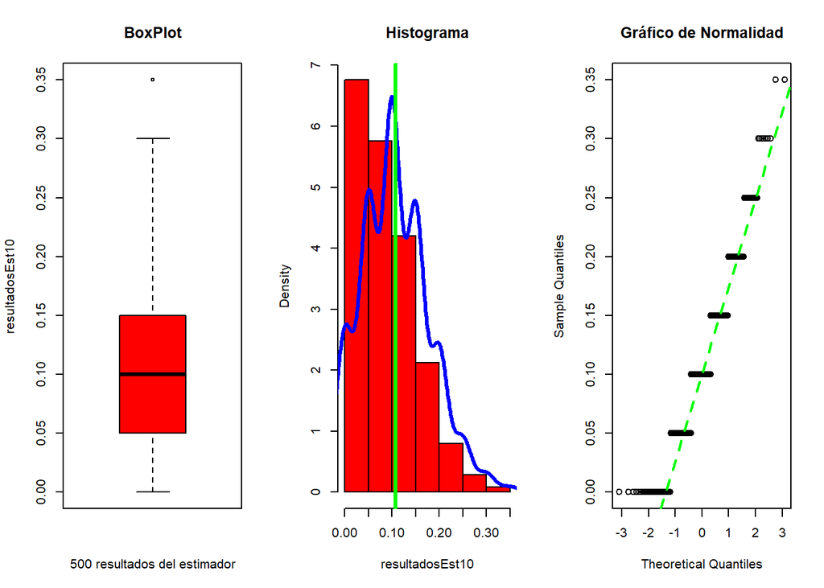

```
##    Min. 1st Qu.  Median    Mean 3rd Qu.    Max.
##   0.000   0.050   0.100   0.108   0.150   0.350
```

**n = 30 y criterio = “enfermas**

```r
Muestra.Aleatoria.n10(30,"enfermas")
```

```
##
##  Shapiro-Wilk normality test
##
## data:  resultadosEst10
## W = 0.95518, p-value = 3.47e-11
```

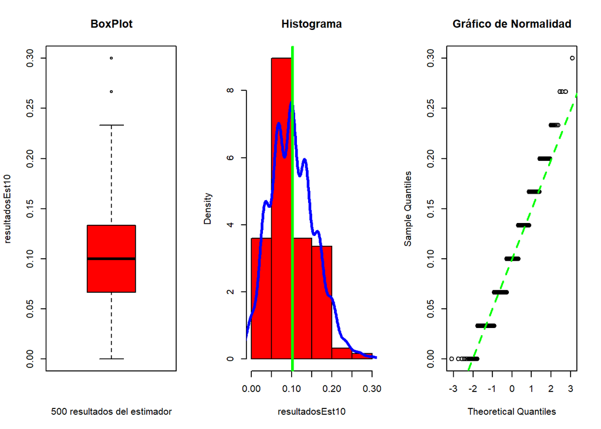

```
##    Min. 1st Qu.  Median    Mean 3rd Qu.    Max.
## 0.00000 0.06667 0.10000 0.10213 0.13333 0.30000
```

**n = 50 y criterio = “enfermas**

```r
Muestra.Aleatoria.n10(50,"enfermas")
```

```
##
##  Shapiro-Wilk normality test
##
## data:  resultadosEst10
## W = 0.97628, p-value = 2.977e-07
```

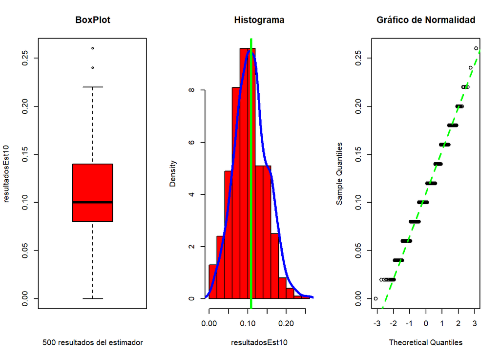

```
##    Min. 1st Qu.  Median    Mean 3rd Qu.    Max.
##   0.000   0.080   0.100   0.109   0.140   0.260
```

**n = 60 y criterio = “enfermas**

```r
Muestra.Aleatoria.n10(60,"enfermas")
```

```
##
##  Shapiro-Wilk normality test
##
## data:  resultadosEst10
## W = 0.9799, p-value = 2.166e-06
```

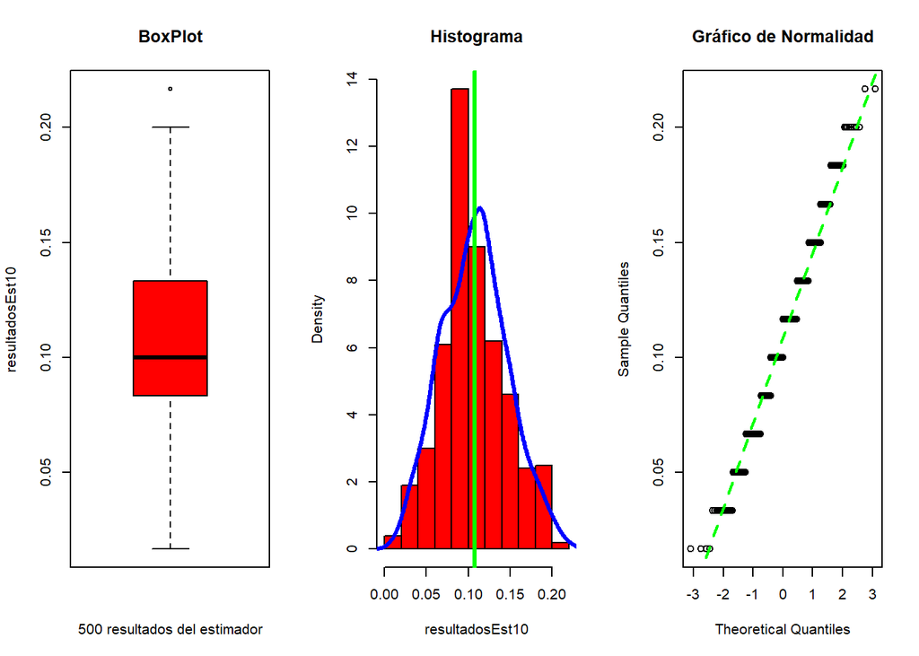

```
##    Min. 1st Qu.  Median    Mean 3rd Qu.    Max.
## 0.01667 0.08333 0.10000 0.10763 0.13333 0.21667
```

**n = 100 y criterio = “enfermas**

```r
Muestra.Aleatoria.n10(100,"enfermas")
```

```
##
##  Shapiro-Wilk normality test
##
## data:  resultadosEst10
## W = 0.98657, p-value = 0.0001443
```

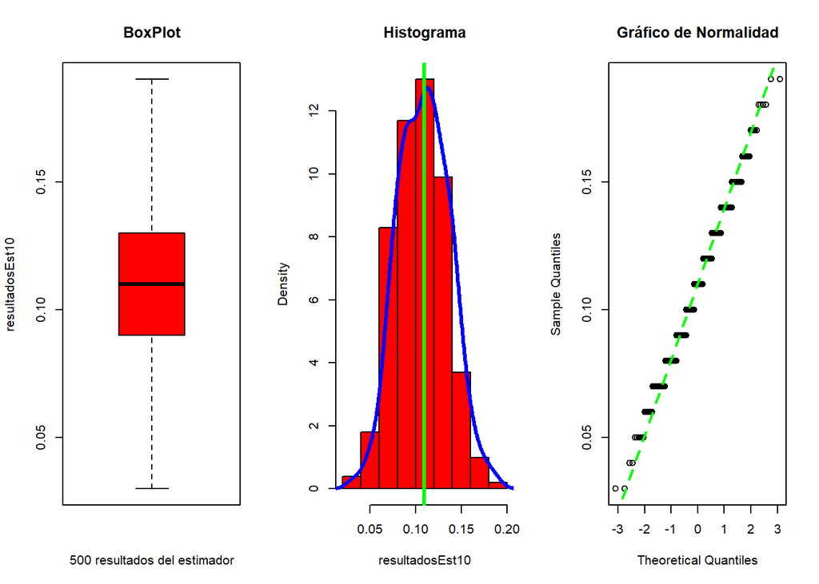

```
##    Min. 1st Qu.  Median    Mean 3rd Qu.    Max.
##  0.0300  0.0900  0.1100  0.1092  0.1300  0.1900
```

**n = 200 y criterio = “enfermas**

```r
Muestra.Aleatoria.n10(200,"enfermas")
```

```
##
##  Shapiro-Wilk normality test
##
## data:  resultadosEst10
## W = 0.99109, p-value = 0.004166
```

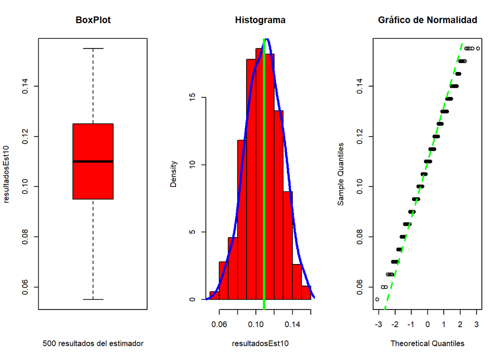

```
##    Min. 1st Qu.  Median    Mean 3rd Qu.    Max.
##  0.0550  0.0950  0.1100  0.1092  0.1250  0.1550
```

**n = 500 y criterio = “enfermas**

```r
Muestra.Aleatoria.n10(500,"enfermas")
```

```
##
##  Shapiro-Wilk normality test
##
## data:  resultadosEst10
## W = 0.9943, p-value = 0.059
```

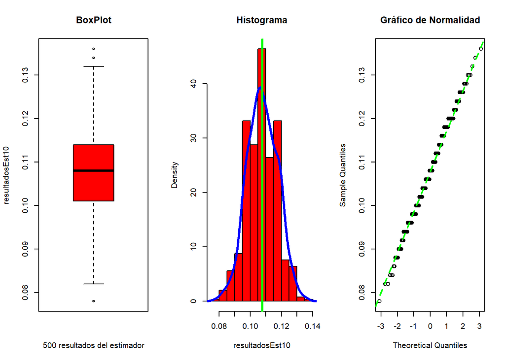

```
##    Min. 1st Qu.  Median    Mean 3rd Qu.    Max.
##  0.0780  0.1015  0.1080  0.1078  0.1140  0.1360
```

y por ultimo, en el lote de $1000$, siguiendo una población con distribución Binomial el porcentaje de individuos enfermos cambia al $90%$, asi:

```r
poblacion90 <- rbinom(1,size=1000,prob=0.9)
```

y ajustamos el mismo código con la nueva población:

```r
P.Enfermas <- poblacion90
P.Sanas <- 1000 - P.Enfermas
Datos.Poblacion90 <- c(rep("enfermas",P.Enfermas), rep("sanas",P.Sanas))

Muestra.Aleatoria90 = function(tamaño,criterio) {
  muestra <- sample(Datos.Poblacion90, size = tamaño)
  P.Muestral <- sum(muestra == criterio)/tamaño
}

Muestra.Aleatoria.n90 = function(tamaño,criterio){
  resultadosEst90 <- array(NA,500)
  for (i in 1:500) {
    resultadosEst90[i] <- Muestra.Aleatoria90(tamaño,criterio)
    }

  #---------------------------------------------------------

  summary(resultadosEst90)

  Shapiro <- shapiro.test(resultadosEst90)
  print(Shapiro)

  par(mfrow= c(1,3))

  boxplot(resultadosEst90,col="red",xlab = "500 resultados del estimador",ylab="resultadosEst90",main="BoxPlot")

  hist(resultadosEst90,col="red",main="Histograma",freq = F)
  r <- density(resultadosEst90)
  lines(r)
  lines(r, col = "blue",lwd = 3)
  promedio = mean(resultadosEst90)
  abline(v=promedio, col="green", lwd=3)

  qqnorm(resultadosEst90,main="Gráfico de Normalidad")
  qqline(resultadosEst90,col = 'green', lwd = 2, lty = 2)

  summary(resultadosEst90)
}
```

**n = 5 y criterio = “enfermas**

```r
Muestra.Aleatoria.n90(5,"enfermas")
```

```
##
##  Shapiro-Wilk normality test
##
## data:  resultadosEst90
## W = 0.72963, p-value < 2.2e-16
```

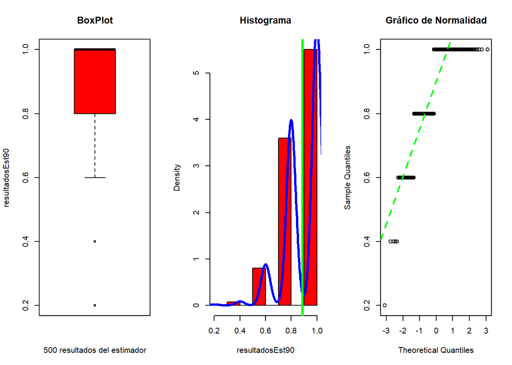

```
##    Min. 1st Qu.  Median    Mean 3rd Qu.    Max.
##  0.2000  0.8000  1.0000  0.8896  1.0000  1.0000
```

**n = 10 y criterio = “enfermas**

```r
Muestra.Aleatoria.n90(10,"enfermas")
```

```
##
##  Shapiro-Wilk normality test
##
## data:  resultadosEst90
## W = 0.83771, p-value < 2.2e-16
```

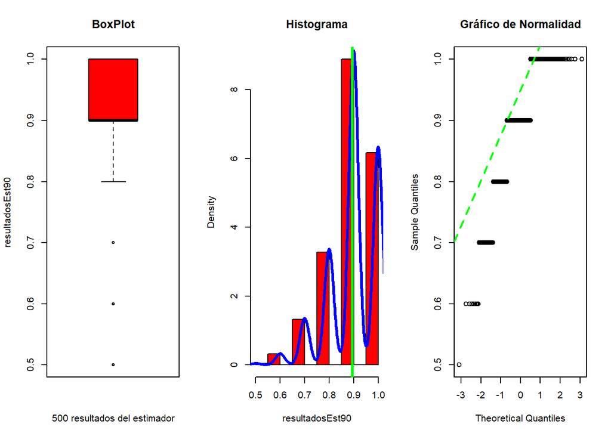

```
##    Min. 1st Qu.  Median    Mean 3rd Qu.    Max.
##  0.5000  0.9000  0.9000  0.8956  1.0000  1.0000
```

**n = 15 y criterio = “enfermas**

```r
Muestra.Aleatoria.n90(15,"enfermas")
```

```
##
##  Shapiro-Wilk normality test
##
## data:  resultadosEst90
## W = 0.89272, p-value < 2.2e-16
```

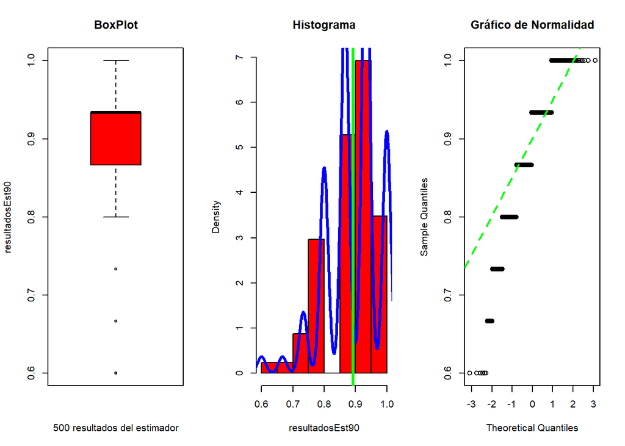

```
##    Min. 1st Qu.  Median    Mean 3rd Qu.    Max.
##  0.6000  0.8667  0.9333  0.8916  0.9333  1.0000
```

**n = 20 y criterio = “enfermas**

```r
Muestra.Aleatoria.n90(20,"enfermas")
```

```
##
##  Shapiro-Wilk normality test
##
## data:  resultadosEst90
## W = 0.92802, p-value = 9.235e-15
```

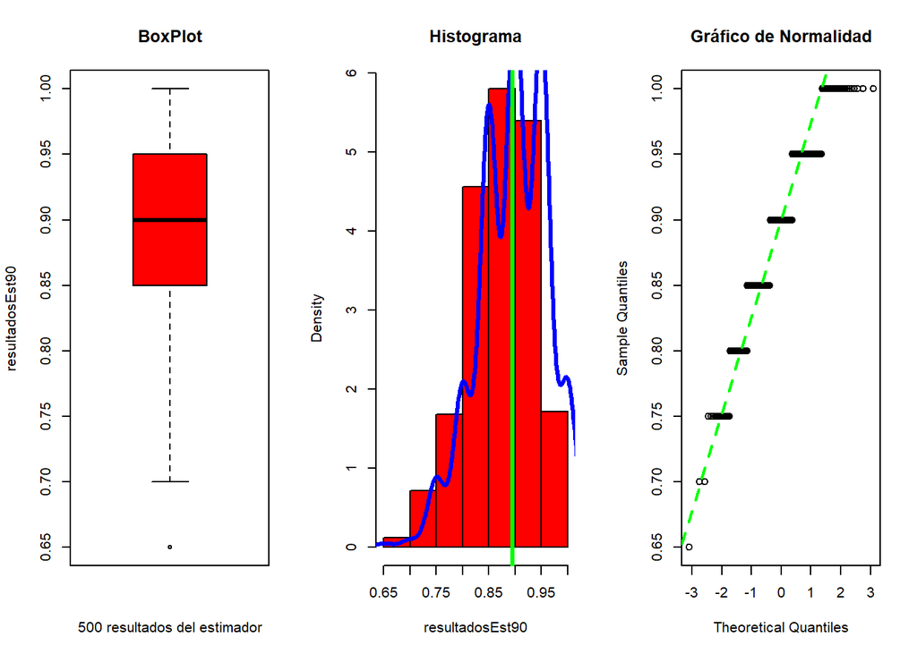

```
##    Min. 1st Qu.  Median    Mean 3rd Qu.    Max.
##  0.6500  0.8500  0.9000  0.8956  0.9500  1.0000
```

**n = 30 y criterio = “enfermas**

```r
Muestra.Aleatoria.n90(30,"enfermas")
```

```
##
##  Shapiro-Wilk normality test
##
## data:  resultadosEst90
## W = 0.95158, p-value = 9.897e-12
```

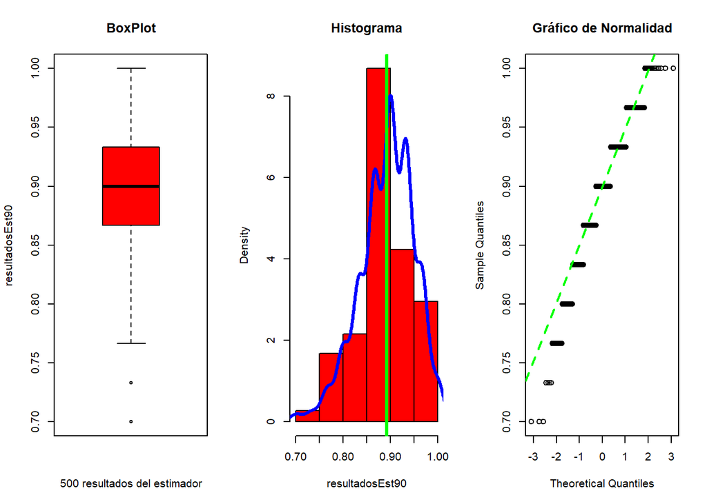

```
##    Min. 1st Qu.  Median    Mean 3rd Qu.    Max.
##  0.7000  0.8667  0.9000  0.8927  0.9333  1.0000
```

**n = 50 y criterio = “enfermas**

```r
Muestra.Aleatoria.n90(50,"enfermas")
```

```
##
##  Shapiro-Wilk normality test
##
## data:  resultadosEst90
## W = 0.96874, p-value = 7.751e-09
```

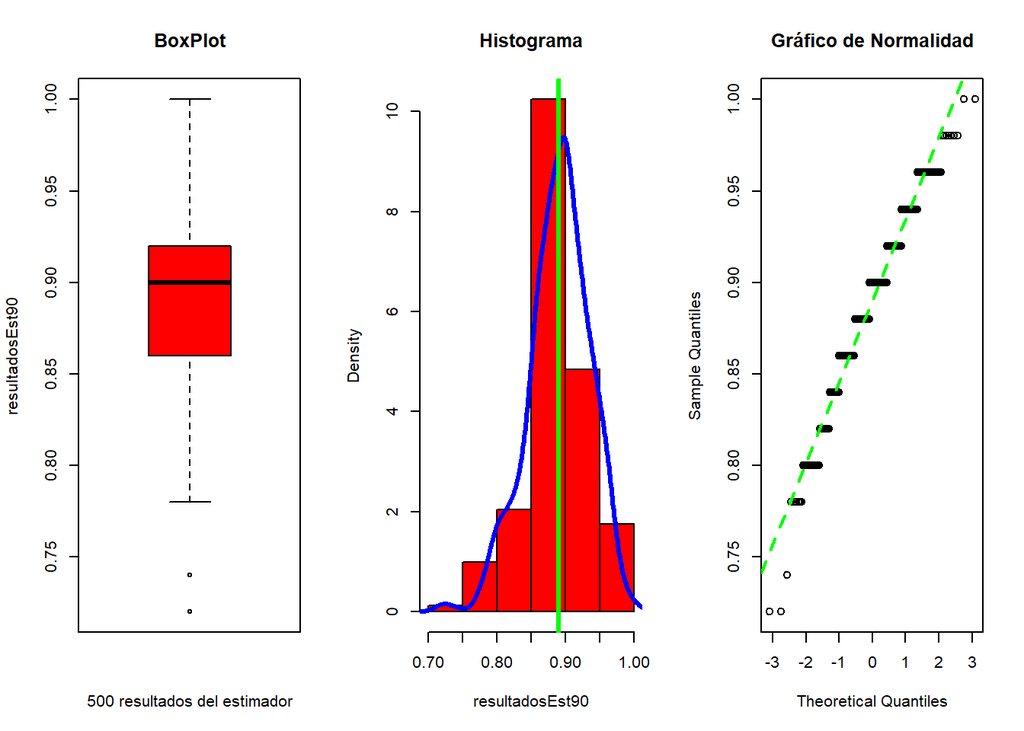

```
##    Min. 1st Qu.  Median    Mean 3rd Qu.    Max.
##  0.7200  0.8600  0.9000  0.8904  0.9200  1.0000
```

**n = 60 y criterio = “enfermas**

```r
Muestra.Aleatoria.n90(60,"enfermas")
```

```
##
##  Shapiro-Wilk normality test
##
## data:  resultadosEst90
## W = 0.97545, p-value = 1.932e-07
```

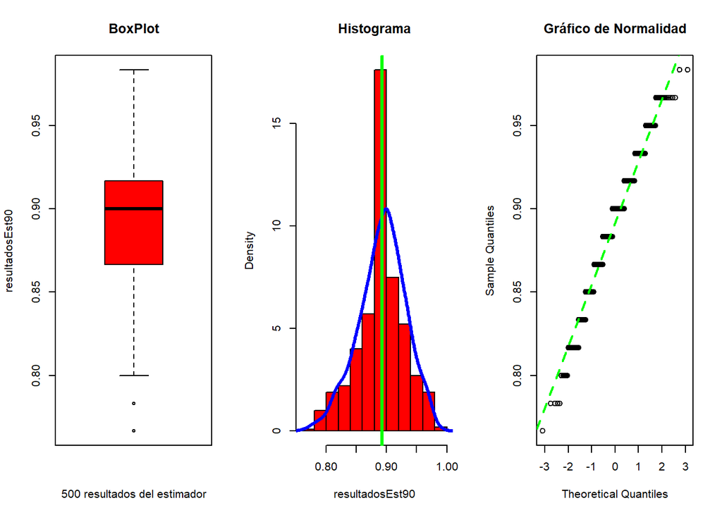

```
##    Min. 1st Qu.  Median    Mean 3rd Qu.    Max.
##  0.7667  0.8667  0.9000  0.8926  0.9167  0.9833
```

**n = 100 y criterio = “enfermas**

```r
Muestra.Aleatoria.n90(100,"enfermas")
```

```
##
##  Shapiro-Wilk normality test
##
## data:  resultadosEst90
## W = 0.97587, p-value = 2.401e-07
```

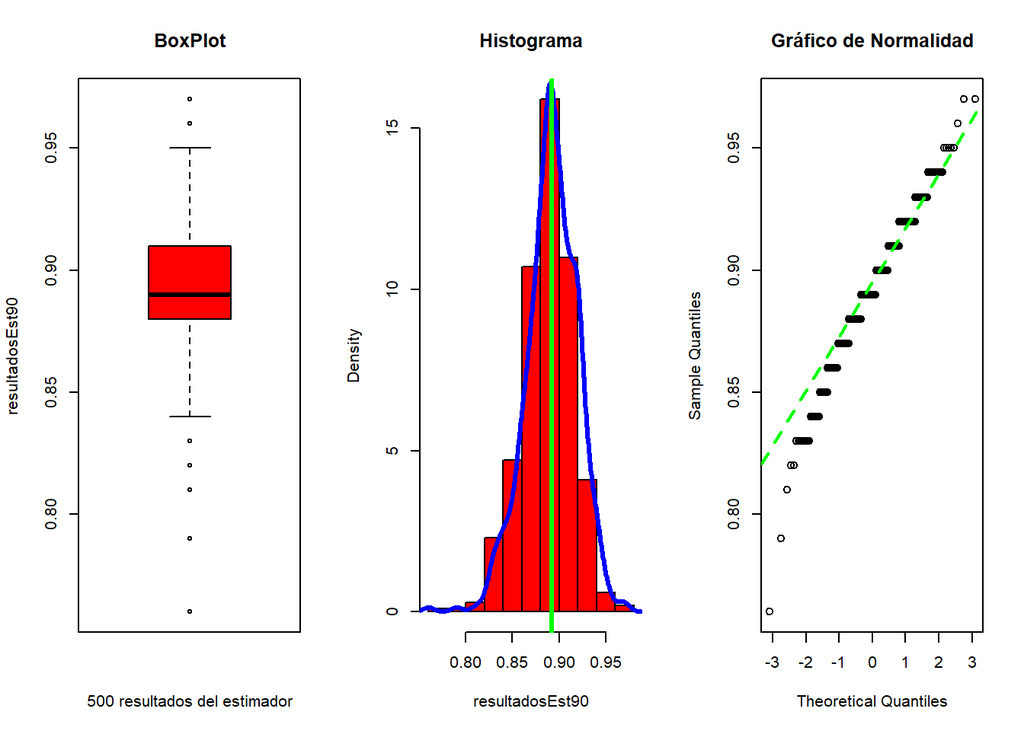

```
##    Min. 1st Qu.  Median    Mean 3rd Qu.    Max.
##   0.760   0.880   0.890   0.892   0.910   0.970
```

**n = 200 y criterio = “enfermas**

```r
Muestra.Aleatoria.n90(200,"enfermas")
```

```
##
##  Shapiro-Wilk normality test
##
## data:  resultadosEst90
## W = 0.99122, p-value = 0.004613
```

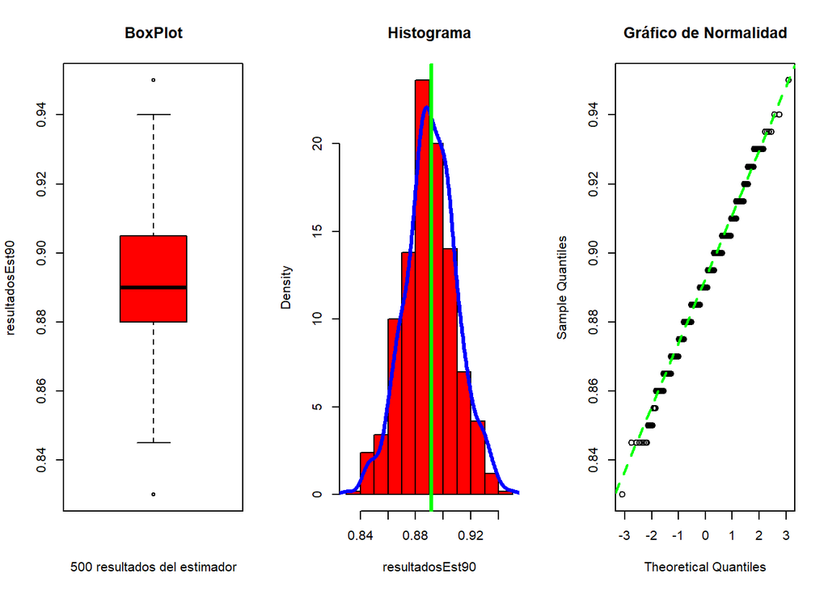

```
##    Min. 1st Qu.  Median    Mean 3rd Qu.    Max.
##  0.8300  0.8800  0.8900  0.8913  0.9050  0.9500
```

**n = 500 y criterio = “enfermas**

```r
Muestra.Aleatoria.n90(500,"enfermas")
```

```
##
##  Shapiro-Wilk normality test
##
## data:  resultadosEst90
## W = 0.99428, p-value = 0.05759
```

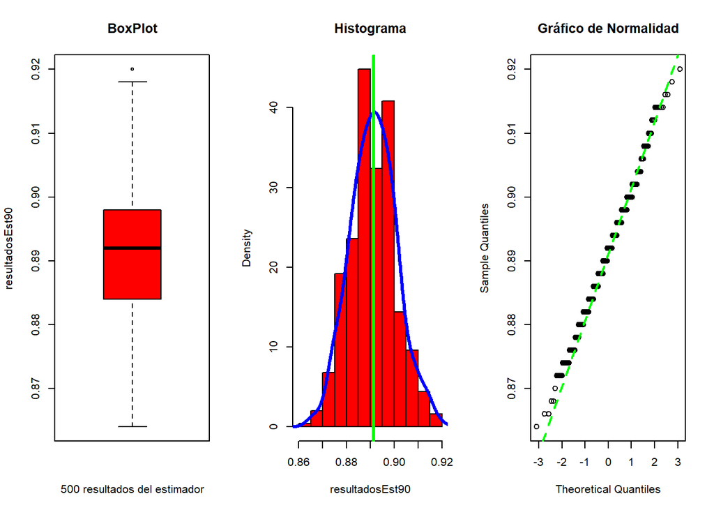

```
##    Min. 1st Qu.  Median    Mean 3rd Qu.    Max.
##  0.8640  0.8840  0.8920  0.8914  0.8980  0.9200
```